# Sentiment-Analysis-Project

2024-12-12

```r
library(dplyr)
```

```r
library(ggplot2)
library(stringr)
library(tidyverse)
library(syuzhet)
tweetsDF <- read.csv("tweetsDf.csv")

full_df <- tweetsDF
```

### Codechunks for modifying/cleaning the dataset

```r
# Codes for cleaning the dataset
clean <- full_df %>%
  mutate(text = str_to_lower(text),
         text = str_remove_all(text, "http\\S+"),
         text = str_remove_all(text, "@\\w+"),
         text = str_remove_all(text, "#\\w+"),
         text = str_remove_all(text, "\\d+"),
         text = str_remove_all(text, "[^\\w\\s]"),
         text = str_squish(text),
         sentiment = get_sentiment(text, method = "bing"))

# Modified the dataset, added a date and hour column converted from the "created" column of tweetsDF
clean <- clean %>%
  mutate(date = ymd_hms(created)) %>%
  mutate(hour = hour(date))
```

### Trend Analysis

For the trend analysis, we focused on the hourly tweet frequencies to observe how tweet activity changed over three distinct days. By examining the tweet count by hour, we aimed to identify moments when engagement spiked, potentially triggered by specific events, updates, or reactions. This analysis provides insights into when users were most active in discussing topics of interest and helps us understand the timeline of information dissemination and public engagement.

```r
# Summarize tweet frequency by hour and group them by day
hourly_tweet_summary <- clean %>%
  group_by(tweet_day = as.Date(date), tweet_hour = hour) %>%
  summarise(tweet_volume = n(), .groups = "drop")

# Split data into separate subsets for plotting by day
day1_tweets_data <- hourly_tweet_summary %>% filter(tweet_day == unique(tweet_day)[1])
day2_tweets_data <- hourly_tweet_summary %>% filter(tweet_day == unique(tweet_day)[2])
day3_tweets_data <- hourly_tweet_summary %>% filter(tweet_day == unique(tweet_day)[3])
```

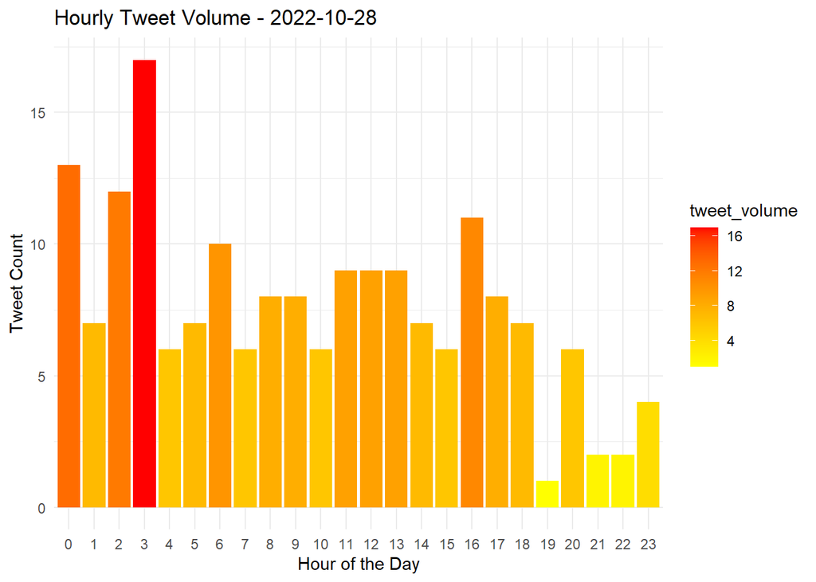

```r
# Graph for the first day
day1_tweet_graph <- ggplot(day1_tweets_data, aes(x = factor(tweet_hour), y = tweet_volume, fill = tweet_volume)) +
  geom_bar(stat = "identity") +
  labs(title = paste("Hourly Tweet Volume -", unique(day1_tweets_data$tweet_day)),
       x = "Hour of the Day",
       y = "Tweet Count") +
  scale_fill_gradient(low = "yellow", high = "red") +
  scale_x_discrete(breaks = as.character(0:23)) +
  theme_minimal()
day1_tweet_graph
```

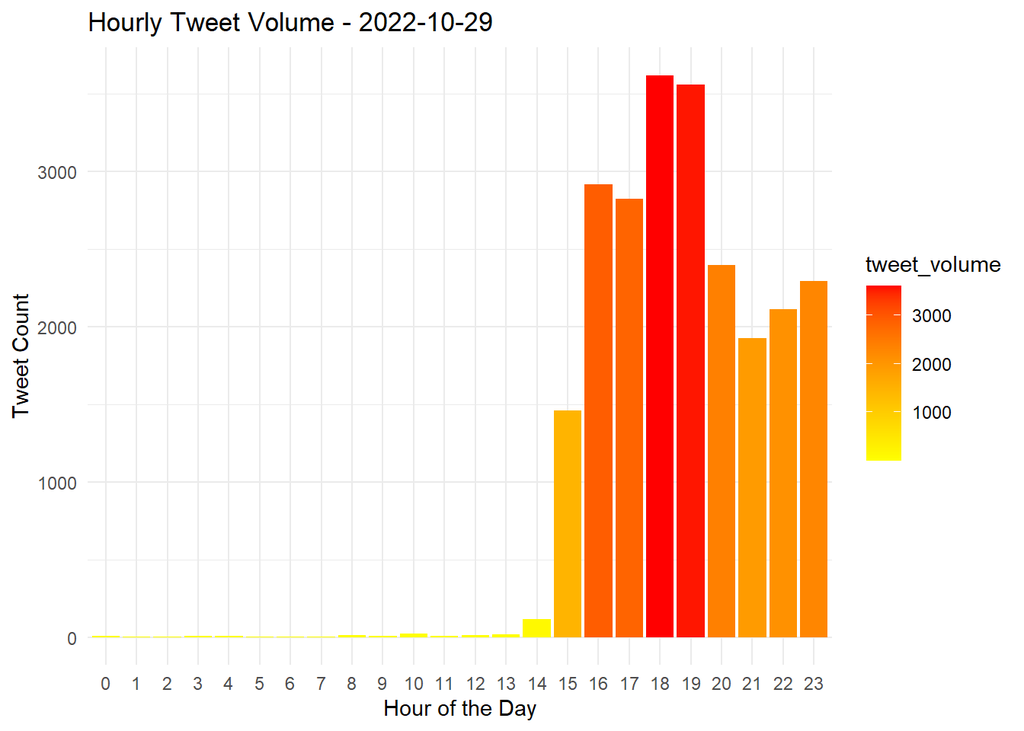

```r
# Graph for the second day
day2_tweet_graph <- ggplot(day2_tweets_data, aes(x = factor(tweet_hour), y = tweet_volume, fill = tweet_volume)) +
  geom_bar(stat = "identity") +
  labs(title = paste("Hourly Tweet Volume -", unique(day2_tweets_data$tweet_day)),
       x = "Hour of the Day",
       y = "Tweet Count") +
  scale_fill_gradient(low = "yellow", high = "red") +
  scale_x_discrete(breaks = as.character(0:23)) +
  theme_minimal()
day2_tweet_graph
```

Day 2 (2022-10-29): The second graph shows a sharp increase in tweet activity starting in the afternoon (around 3 PM), with a pronounced peak around 6 PM. This spike likely corresponds to the unfolding of the incident or the public becoming aware of breaking news. Social media activity during this time highlights its role as a platform for real-time information sharing and reactions to unfolding events.

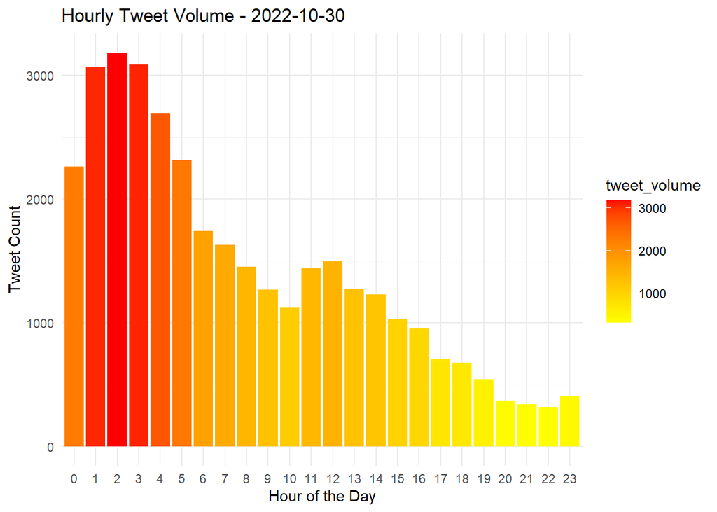

```r
# Graph for the third day
day3_tweet_graph <- ggplot(day3_tweets_data, aes(x = factor(tweet_hour), y = tweet_volume, fill = tweet_volume)) +
  geom_bar(stat = "identity") +
  labs(title = paste("Hourly Tweet Volume -", unique(day3_tweets_data$tweet_day)),
       x = "Hour of the Day",
       y = "Tweet Count") +
  scale_fill_gradient(low = "yellow", high = "red") +
  scale_x_discrete(breaks = as.character(0:23)) +
  theme_minimal()
day3_tweet_graph
```

Day 3 (2022-10-30): The third graph displays a high volume of tweets during the early morning hours (midnight to 3 AM), followed by a gradual decline throughout the day. The elevated activity during the early hours reflects continued discussions, reactions, or updates related to the event. The decline in tweet volume later in the day suggests that the immediate emotional response subsided, giving way to more measured and less frequent discussions.

### Sentiment Analysis

For the sentiment analysis, we categorized tweets into three sentiment categories: Positive, Neutral, and Negative. By analyzing the distribution of these sentiments by hour, we aimed to understand the emotional tone of tweets and observe how sentiments shifted over time. This analysis provides insights into how people reacted emotionally to events and their progression over the three days.

```r
# Categorize sentiment into Positive, Neutral, and Negative by hour per day
hourly_sentiment_summary <- clean %>%
  mutate(sentiment_label = ifelse(sentiment > 0, "Positive",
                                   ifelse(sentiment < 0, "Negative", "Neutral"))) %>%
  group_by(tweet_day = as.Date(date), tweet_hour = hour, sentiment_label) %>%
  summarise(sentiment_count = n(), .groups = "drop")

# Filter each day's data for plotting graphs
day1_sentiment_data <- hourly_sentiment_summary %>% filter(tweet_day == unique(tweet_day)[1])
day2_sentiment_data <- hourly_sentiment_summary %>% filter(tweet_day == unique(tweet_day)[2])
day3_sentiment_data <- hourly_sentiment_summary %>% filter(tweet_day == unique(tweet_day)[3])
```

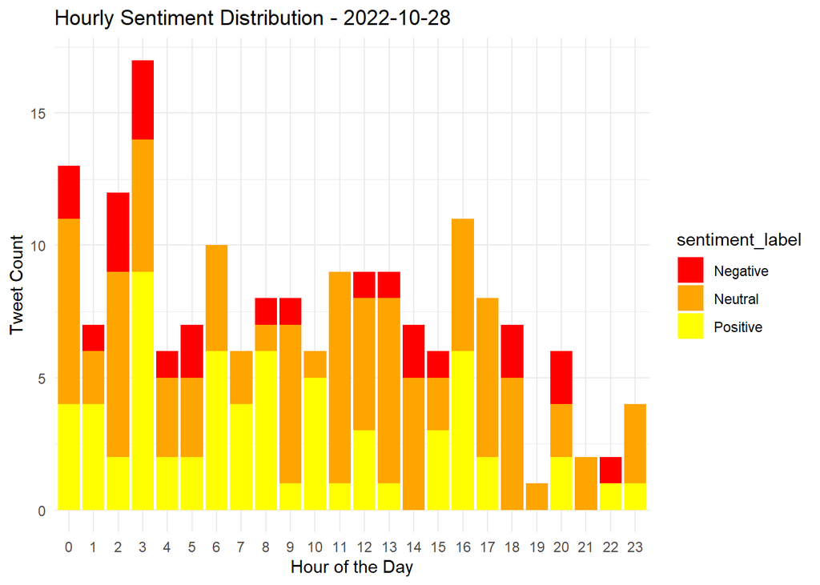

```r
# Plot sentiment trends for the first day
day1_sentiment_graph <- ggplot(day1_sentiment_data, aes(x = factor(tweet_hour), y = sentiment_count, fill = sentiment_label)) +
  geom_bar(stat = "identity", position = "stack") +
  labs(title = paste("Hourly Sentiment Distribution -", unique(day1_sentiment_data$tweet_day)),
       x = "Hour of the Day",
       y = "Tweet Count") +
  scale_fill_manual(values = c("red", "orange", "yellow")) +
  scale_x_discrete(breaks = as.character(0:23)) +
  theme_minimal()
day1_sentiment_graph
```

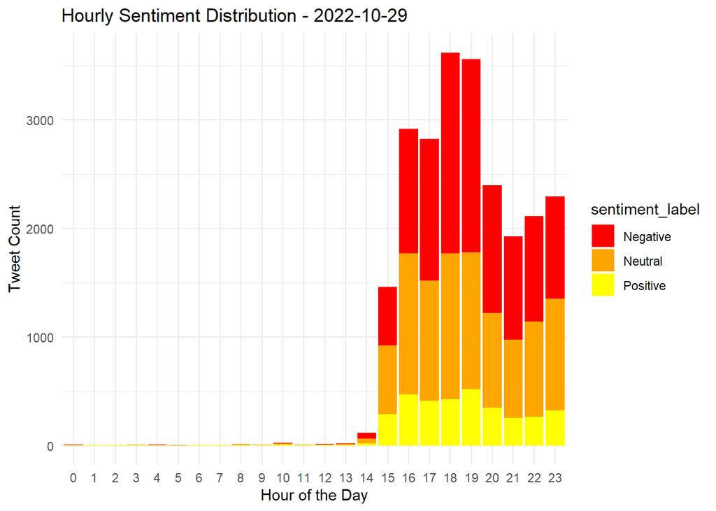

```r
# Plot sentiment trends for the second day
day2_sentiment_graph <- ggplot(day2_sentiment_data, aes(x = factor(tweet_hour), y = sentiment_count, fill = sentiment_label)) +
  geom_bar(stat = "identity", position = "stack") +
  labs(title = paste("Hourly Sentiment Distribution -", unique(day2_sentiment_data$tweet_day)),
       x = "Hour of the Day",
       y = "Tweet Count") +
  scale_fill_manual(values = c("red", "orange", "yellow")) +
  scale_x_discrete(breaks = as.character(0:23)) +
  theme_minimal()
day2_sentiment_graph
```

Day 2 (2022-10-29): This graph shows a sharp increase in tweet activity during the afternoon and evening hours, with Negative sentiments dominating during these peaks. The predominance of negative sentiments aligns with the likely timing of an incident that provoked strong emotional responses, such as frustration, grief, or shock. Social media activity during this time reflects the immediate emotional reaction of users to unfolding events.

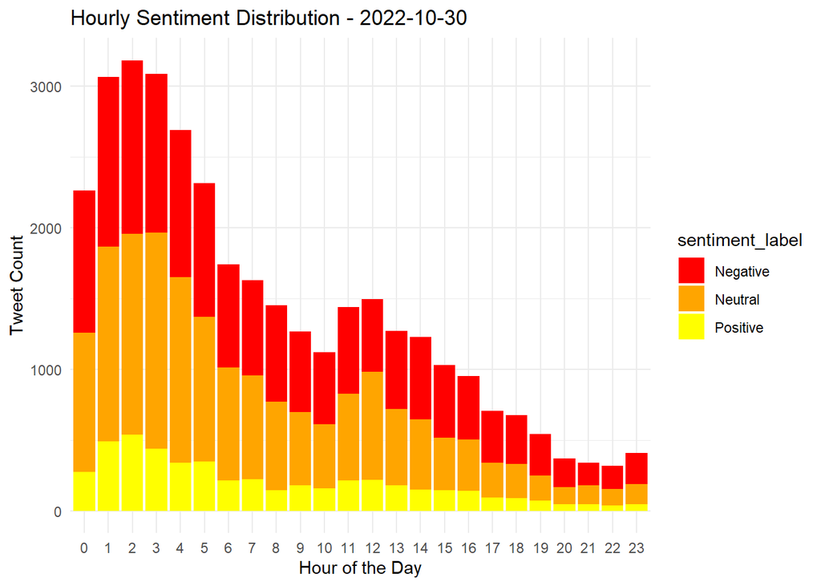

```r
# Plot sentiment trends for the third day
day3_sentiment_graph <- ggplot(day3_sentiment_data, aes(x = factor(tweet_hour), y = sentiment_count, fill = sentiment_label)) +
  geom_bar(stat = "identity", position = "stack") +
  labs(title = paste("Hourly Sentiment Distribution -", unique(day3_sentiment_data$tweet_day)),
       x = "Hour of the Day",
       y = "Tweet Count") +
  scale_fill_manual(values = c("red", "orange", "yellow")) +
  scale_x_discrete(breaks = as.character(0:23)) +
  theme_minimal()
day3_sentiment_graph
```